# Music analysis

Nenad Shurbevski BF1-EN

2022-06-17

# Introduction: What is spotify?

Spotify is a digital music streaming service that gives you access to millions of songs, podcasts and videos from artists all over the world. Spotify is immediately appealing because you can access content for free by simply signing up using an email address or by connecting with Facebook. If you’re not keen on monthly subscription fees for Spotify Premium, or just want to dip your toe in and test it out, it’s easy to get started and there’s no commitment.

Spotify is smart too, the more you listen, the more it learns the sort of music you like and that has an impact on the music it will present to you in future. Creating playlists is also super easy! Spotify also gives the user the opportunity to create a playlist for his/hers pet, allowing them to spend some quality time together!

## Analyzing songs

Spotify is the home of millions of songs. They have a wide range of songs from different genres, length, popularity etc. This data set contains audio statistics of the top 2000 tracks on Spotify. Songs released from 1956 to 2019 are included from some notable and famous artists like Queen, The Beatles, Guns N’ Roses, etc. The aim of this data set is to explore and find out unique links between songs in the Top 2000s.This data set has unique charachterstics such as:

- Beats per minute
- Danceability
- Energy
- Loudness
- Speechiness (the number of spoken words the song contains) etc.

To analyse the data, we use the following libraries:

```r
library(tidyverse)
```

```r
library(ggplot2)
library(gganimate)
x<-read.csv("Spotify-2000.csv")
```

So, judging by this data set, the top 10 songs that have the highest tempo(BPM) until 2019 were:

```r
names(x)[names(x) == "Beats.Per.Minute..BPM."] <- "BPM"

y<-select(x,"Artist","Title", "BPM")%>%filter(BPM>=198 & BPM<=206)
y[order(y$BPM, decreasing = TRUE),]->y
y
```

```
##                   Artist
## 8                 R.E.M.
## 1     The Rolling Stones
## 6           Dolly Parton
## 10 Red Hot Chili Peppers
## 4            Marvin Gaye
## 9                Nirvana
## 5                   ABBA
## 2            Rowwen Hèze
## 3            Andre Hazes
## 7                 Prince
##                                                        Title BPM
## 8  It's The End Of The World As We Know It (And I Feel Fine) 206
## 1                 Lady Jane - (Original Single Mono Version) 205
## 6                                      Islands In the Stream 204
## 10                                             Road Trippin' 204
## 4                                            What's Going On 203
## 9                                           Heart-Shaped Box 203
## 5                                    Thank You For The Music 200
## 2                                           De Peel In Brand 199
## 3                                        Een Beetje Verliefd 198
## 7                                         Sign 'O' the Times 198
```

Out of these songs, the one with the highest danceability is:

```r
y1<-select(x,"Artist","Title", "BPM","Danceability")%>%filter(BPM>=198 & BPM<=206)%>%filter(Danceability==70)
y1
```

```
##   Artist              Title BPM Danceability
## 1 Prince Sign 'O' the Times 198           70
```

So if you are ever in a bad mood, play this song and start dancing.

Now, I wanted to compare the songs from 1980 to 2000, which in my opinion are the best decades for music, that had 200+ BPM. I represent that on the following ggplot:

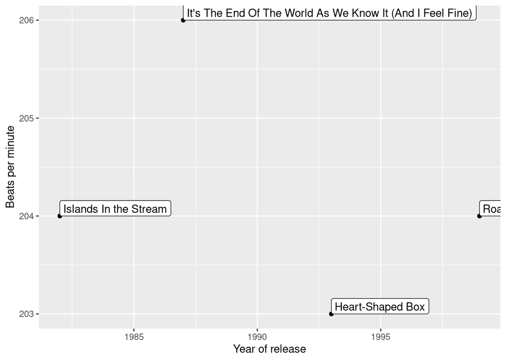

```r
z<-select(x,"Artist","Title","Year", "BPM")%>%filter(Year>=1980 & Year<=2000 & BPM>=200)
ggplot(z, aes(x=Year, y=BPM, label = Title))+geom_point()+geom_label(hjust=0, vjust=0)+labs(y= "Beats per minute", x = "Year of release")->a
a
```

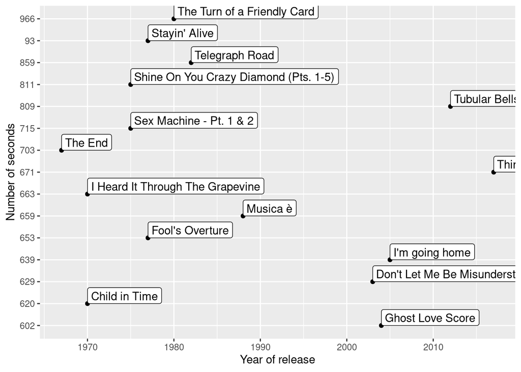

```r
z1<-select(x,"Artist","Title","Year", "Length..Duration.")%>%filter(Year>=1950 & Length..Duration.>=600)
ggplot(z1, aes(x=Year, y=Length..Duration., label = Title))+geom_point()+geom_label(hjust=0, vjust=0) +labs(y= "Number of seconds", x = "Year of release")->b
b
```

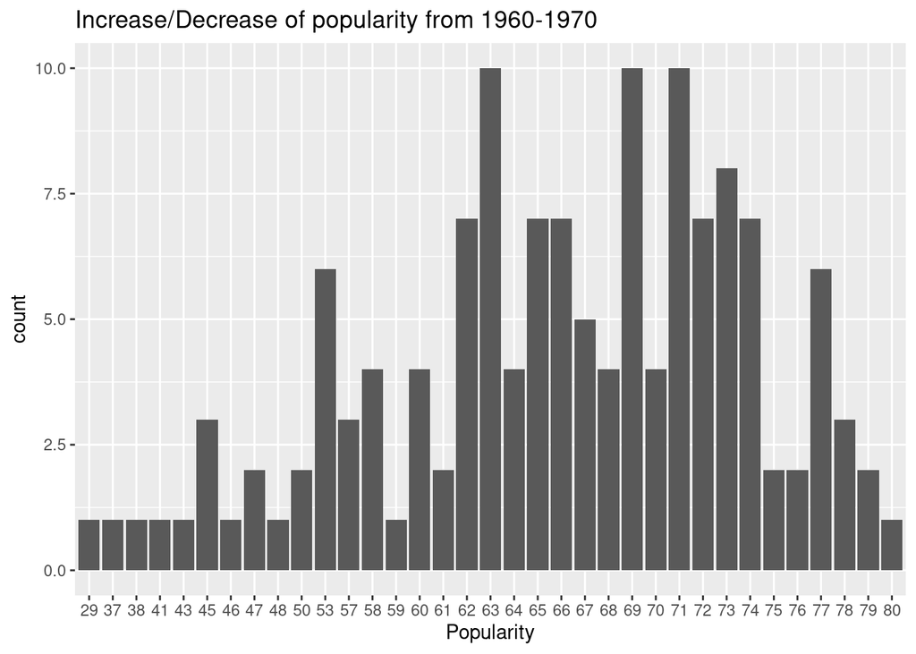

```r
k<-select(x,"Artist","Title","Year", "Popularity")%>%filter(Year>=1960 & Year<=1970)
ggplot(k) + geom_bar(aes(x = factor(Popularity))) +
  labs(title = 'Increase/Decrease of popularity from 1960-1970', x = "Popularity")->j
j
```

### Conclusion

In general, this data set provides a lot of interesting stats. Taking into consideration my analysis, we can conclude that judging by this data set, there isn’t really any pattern in music in terms of, lets say, BPM. The songs that had a high BPM count were from various decades, meaning that music isn’t dependent on any factors other than how it is percieved by the listener.